# P2. Investigate a Dataset

## 1. Dataset chosen for analysis: Baseball Data

A data set containing complete batting and pitching statistics from 1871 to 2014, plus fielding statistics, standings, team stats, managerial records, post-season data, and more.

## 2. Questions Posed

### * From which State most of the successfull players come from?

### * What type of players get higher salary than others - a Correlation between salary and performance of players.

### * Find the players which have played for a team for more than 12 years?

### * Finding those players who were managers for a team and had played for the same team, this does not include player-managers?

### * Descriptive statistics of salaries of player.

## 3. Description of the Dataset

The design follows these general principles. Each player is assigned a unique number (playerID). All of the information relating to that player is tagged with his playerID. The playerIDs are linked to names and birthdates in the MASTER table.

The database is comprised of the following main tables:

- MASTER - Player names, DOB, and biographical info
- Batting - batting statistics
- Pitching - pitching statistics
- Fielding - fielding statistics

It is supplemented by these tables:

- AllStarFull - All-Star appearances
- HallofFame - Hall of Fame voting data
- Managers - managerial statistics
- Teams - yearly stats and standings
- BattingPost - post-season batting statistics
- PitchingPost - post-season pitching statistics
- TeamFranchises - franchise information
- FieldingOF - outfield position data
- FieldingPost- post-season fieldinf data
- ManagersHalf - split season data for managers
- TeamsHalf - split season data for teams
- Salaries - player salary data
- SeriesPost - post-season series information
- AwardsManagers - awards won by managers
- AwardsPlayers - awards won by players
- AwardsShareManagers - award voting for manager awards
- AwardsSharePlayers - award voting for player awards
- Appearances - details on the positions a player appeared at
- Schools - list of colleges that players attended
- CollegePlaying - list of players and the colleges they attended

### There are a total of 24 dataset here. For the purpose of this project I have chosen the following datasets.

**1. MASTER table**

- playerID ---> A unique code asssigned to each player. The playerID links the data in this file with records in the other files.
- birthYear ---> Year player was born
- birthMonth ---> Month player was born
- birthDay ---> Day player was born
- birthCountry ---> Country where player was born
- birthState ---> State where player was born
- birthCity ---> City where player was born
- deathYear ---> Year player died
- deathMonth ---> Month player died
- deathDay ---> Day player died
- deathCountry ---> Country where player died
- deathState ---> State where player died
- deathCity ---> City where player died
- nameFirst ---> Player's first name
- nameLast ---> Player's last name
- nameGiven ---> Player's given name (typically first and middle)
- weight ---> Player's weight in pounds
- height ---> Player's height in inches
- bats ---> Player's batting hand (left, right, or both)
- throws ---> Player's throwing hand (left or right)
- debut ---> Date that player made first major league appearance
- finalGame ---> Date that player made first major league appearance (blank if still active)
- retroID ---> ID used by retrosheet
- bbrefID ---> ID used by Baseball Reference website

**2. Batting Table**

- playerID ---> Player ID code
- yearID ---> Year
- stint ---> player's stint (order of appearances within a season)
- teamID ---> Team
- lgID ---> League
- G ---> Games
- AB ---> At Bats
- R ---> Runs
- H ---> Hits
- 2B ---> Doubles
- 3B ---> Triples
- HR ---> Homeruns
- RBI ---> Runs Batted In
- SB ---> Stolen Bases
- CS ---> Caught Stealing
- BB ---> Base on Balls
- SO ---> Strikeouts
- IBB ---> Hit by pitch
- SH ---> Sacrifice hits
- SF ---> Sacrifice flies
- GIDP ---> Grounded into double plays

**3. Pitching table**

- playerID ---> Player ID code
- yearID ---> Year
- stint ---> player's stint (order of appearances within a season)
- teamID ---> Team
- lgID ---> League
- W ---> Wins
- L ---> Losses
- G ---> Games
- GS ---> Games Started
- CG ---> Complete Games
- SHO ---> Shutouts
- SV ---> Saves
- IPOuts ---> Outs Pitched (innings pitched x 3)
- H ---> Hits
- ER ---> Earned Runs
- HR ---> Homeruns
- BB ---> Walks
- SO ---> Strikeouts
- BAOpp ---> Opponent's Batting Average
- ERA ---> Earned Run Average
- IBB ---> Intentional Walks
- WP ---> Wild Pitches
- HBP ---> Batters Hit By Pitch
- BK ---> Balks
- BFP ---> Batters faced by Pitcher
- GF ---> Games Finished
- R ---> Runs Allowed
- SH ---> Sacrifices by opposing batters
- SF ---> Sacrifice flies by opposing batters
- GIDP ---> Grounded into double plays by opposing batter

**4. Managers table**

- playerID ---> Player ID Number
- yearID ---> Year
- teamID ---> Team
- lgID ---> League
- inseason ---> Managerial order. Zero if the individual managed the team the entire year. Otherwise denotes where the manager appeared in the managerial order (1 for first manager, 2 for second, etc.)
- G ---> Games managed
- W ---> Wins
- L ---> Losses
- rank ---> Team's final position in standings that year
- plyrMgr ---> Player Manager (denoted by 'Y')

**5 Teams table**

- yearID ---> Year
- lgID ---> League
- teamID ---> Team
- franchID ---> Franchise (links to TeamsFranchise table)
- divID ---> Team's division
- Rank ---> Position in final standings
- G ---> Games played
- GHome ---> Games played at home
- W ---> Wins
- L ---> Losses
- DivWin ---> Division Winner (Y or N)
- WCWin ---> Wild Card Winner (Y or N)
- LgWin ---> League Champion(Y or N)
- WSWin ---> World Series Winner (Y or N)
- R ---> Runs scored
- AB ---> At bats
- H ---> Hits by batters
- 2B ---> Doubles
- 3B ---> Triples
- HR ---> Homeruns by batters
- BB ---> Walks by batters
- SO ---> Strikeouts by batters
- SB ---> Stolen bases
- CS ---> Batters hit by pitch
- SF ---> Sacrifice flies
- RA ---> Opponents runs scored
- ER ---> Earned runs allowed
- ERA ---> Earned run average
- CG ---> Complete games
- SHO ---> Shutouts
- SV ---> Saves
- IPOuts ---> Outs Pitched (innings pitched x 3)
- HA ---> Hits allowed
- HRA ---> Homeruns allowed
- BBA ---> Walks allowed
- SOA ---> Strikeouts by pitchers
- E ---> Errors
- DP ---> Double Plays
- FP ---> Fielding percentage
- name ---> Team's full name
- park ---> Name of team's home ballpark
- attendance ---> Home attendance total
- BPF ---> Three-year park factor for batters
- PPF ---> Three-year park factor for pitchers
- teamIDBR ---> Team ID used by Baseball Reference website
- teamIDlahman45---> Team ID used in Lahman database version 4.5
- teamIDretro ---> Team ID used by Retrosheet

**6. Salaries table**

- yearID ---> Year
- teamID ---> Team
- lgID ---> League
- playerID ---> Player ID code
- salary ---> Salary

**7. Schools table**

- schoolID ---> school ID code
- schoolName ---> school name
- schoolCity ---> city where school is located
- schoolState ---> state where school's city is located
- schoolNick ---> nickname for school's baseball team

**8. CollegePlaying table**

- playerid ---> Player ID code
- schoolID ---> school ID code
- year ---> year

**9. AwardsManagers table**

- playerID ---> Manager ID code
- awardID ---> Name of award won
- yearID ---> Year
- lgID ---> League
- tie ---> Award was a tie (Y or N)
- notes ---> Notes about the award

# 4. Data Wrangling

Here we can see that there is too much of data for us to analyze. So for the purpose of this project for the first three questions, I will be looking at the statistics for last 2 decades.

## Steps Involved:

## a. Loading the data in IPython Notebook

```python
##Loading the data into dataframes

import pandas as pd
import numpy as np
import matplotlib.pyplot as plt
import seaborn as sns
%pylab inline
```

```python
def read_data(file):

    data = pd.read_csv("C:/Users/anich/Documents/Baseball 2017 Project/"+file)
    return data

master_data = read_data('Master.csv')
batter_data = read_data('Batting.csv')
pitching_data = read_data('Pitching.csv')
fielding_data = read_data('Fielding.csv')
manager_data = read_data('Managers.csv')
team_data = read_data('Teams.csv')
salary_data = read_data('Salaries.csv')
manager_award_data = read_data('AwardsManagers.csv')
school_data = read_data('Schools.csv')
college_data = read_data('CollegePlaying.csv')
```

## b. Filtering the dataset

#### Finding the top 10 Teams of last 2 decades.

#### While exploring each table we can see that there are some fields which are useful for my analysis while some are not. So I will be creating views of tables with fields i need for my analysis. Here first of all i will be deciding the threshold value for year ie. between how many years i will be analyzing my dataset. In this project i am looking at the stats for batters and pitchers only not the fielders.Here are steps for finding out the top 10 teams.

#### 1. So first I filtered the whole data to take entries from the year 1990 till current date. Basically i want to take the data from last 2 decades.

#### 2. Next I found the teams which had won the world series and leagues in that interval.

#### 3. After that i combined both league data and world series data to find a combined stat of all the teams.

#### 4. Finally i sorted the data according to most world series and league wins and found out the top ten teams in the current time interval.

#### 5. Now for the rest of the exploration purpose i will be looking at the players of these top 10 teams only. By this way i will get good idea about the performance of player , get to know the top players in baseball, their salary stats etc.

```python
##Filtering the data for taking team stats from the last 2 decades
new_team_data = team_data[(team_data['yearID'] >= 1990)]


##Finding the teams which has won the league or world series

leaguewin_teams_data = (new_team_data[(new_team_data['LgWin'] == 'Y')])
worldswin_teams_data = (new_team_data[(new_team_data['WSWin'] == 'Y')])

##grouping the teams that won league and that won world series.
league_grouped_teams_data = leaguewin_teams_data.groupby('teamID', as_index = False)[['yearID','LgWin']]
world_grouped_teams_data = worldswin_teams_data.groupby('teamID', as_index = False)[['yearID','WSWin']]

##combining the data sets
combined_world_grouped_teams_data = world_grouped_teams_data.count()
combined_league_grouped_teams_data = league_grouped_teams_data.count()
total_winning_stat = combined_world_grouped_teams_data.merge(combined_league_grouped_teams_data, on='teamID', how ='inner')

##Sorting the data and finding top ten teams of the last 2 decades.
sorted_data = total_winning_stat[['teamID','LgWin','WSWin']].sort_values(['WSWin','LgWin'], ascending=False)
top_ten = sorted_data.iloc[0:10]
top_ten = top_ten.reset_index(drop=True)

print("Top 10 Teams of last 2 decades")
top_ten
```

```
Top 10 Teams of last 2 decades
```

|  | teamID | LgWin | WSWin |
| --- | --- | --- | --- |
| 0 | NYA | 7 | 5 |
| 1 | SFN | 4 | 3 |
| 2 | BOS | 3 | 3 |
| 3 | SLN | 4 | 2 |
| 4 | FLO | 2 | 2 |
| 5 | TOR | 2 | 2 |
| 6 | ATL | 5 | 1 |
| 7 | PHI | 3 | 1 |
| 8 | KCA | 2 | 1 |
| 9 | ANA | 1 | 1 |

#### FInding out the top 100 batters and pitchers who played in the top 10 teams

#### 1. Here also i am considering batsmen and pitchers from the year 1990 till current date. First i am extracting the fields required for finding various batter and pitcher stat required for deciding their performance.

#### 2. Then we merge the new data with the top ten teams data and keep only those players which are present in both tables.By doing this we are assured to get the good players.

#### 3. Next I am taking out the variables we need for our analysis like Batting Average and WHIP. I am applying conditions or range of the variables so that we can get the best players for eg. number of Atbats should be greater than 180 since there are many players who have played 1 or 2 match and their average crosses .400 which should not be the case. After this we group the data by playerid and find the mean figure to get individual performance stat.

#### 4. Then sort the data in descending order to get top 100 players.

```python
##Filtering the data for taking batter stats from the last 2 decades
new_batter_data = batter_data[(batter_data['yearID'] >= 1990)]

##Extracting fields required for taking out batter stats.
new_batter_data = new_batter_data[['playerID','yearID','teamID','G','AB','R','H','HR','RBI','SO']]


##Merging top 10 teams data with player data so that we get the players linked to those teams
merged_batter_data = new_batter_data.merge(top_ten, on='teamID', how = 'inner')

#Adding a new field Batting average for each batter and dropping NaN values if found
merged_batter_data['Batting Average'] = merged_batter_data['H']/merged_batter_data['AB'] *1.0
merged_batter_data = merged_batter_data.dropna()


##Chosing the minimum number  of AtBats to be 180 since there are cases where hits and Atbats are vey less and their batting
##average crosses .400 which should not happen since their hits are less than 100.
merged_batter_data = merged_batter_data[(merged_batter_data['AB']>=180) & (merged_batter_data['Batting Average'] >= 0.300)]
merged_batter_data = merged_batter_data.groupby('playerID' , as_index=False).mean()[['playerID','Batting Average','HR','RBI','R']]
batter_sorted_data = merged_batter_data[['playerID','Batting Average','HR','RBI','R']].sort_values(['RBI','Batting Average','HR','R'], ascending=False)

#rounding off data to take out exact figures for each field
batter_sorted_data = batter_sorted_data.round(3)
batter_sorted_data[['HR','R']] = np.round(batter_sorted_data[['HR','R']],0)

#taking out top 100 batters of the last 2 decades
batter_top100_data = batter_sorted_data.iloc[0:100]
batter_top100_data = batter_top100_data.reset_index(drop=True)

print("Data showing top 100 batter with their IDs and stats")
batter_top100_data
```

```
Data showing top 100 batter with their IDs and stats
```

|  | playerID | Batting Average | HR | RBI | R |
| --- | --- | --- | --- | --- | --- |
| 0 | howarry01 | 0.313 | 58.0 | 149.000 | 104.0 |
| 1 | delgaca01 | 0.316 | 39.0 | 132.333 | 104.0 |
| 2 | rodrial01 | 0.312 | 46.0 | 129.667 | 124.0 |
| 3 | guerrvl01 | 0.337 | 39.0 | 126.000 | 124.0 |
| 4 | pujolal01 | 0.332 | 41.0 | 123.000 | 119.0 |
| 5 | greensh01 | 0.309 | 42.0 | 123.000 | 134.0 |
| 6 | giambja01 | 0.314 | 41.0 | 122.000 | 120.0 |
| 7 | lowelmi01 | 0.324 | 21.0 | 120.000 | 79.0 |
| 8 | dyeje01 | 0.321 | 33.0 | 118.000 | 107.0 |
| 9 | gonzaad01 | 0.338 | 27.0 | 117.000 | 108.0 |
| 10 | kentje01 | 0.323 | 35.0 | 116.500 | 108.0 |
| 11 | cabremi01 | 0.327 | 31.0 | 116.333 | 103.0 |
| 12 | matsuhi01 | 0.305 | 23.0 | 116.000 | 108.0 |
| 13 | ramirma02 | 0.322 | 38.0 | 113.600 | 96.0 |
| 14 | bettsmo01 | 0.318 | 31.0 | 113.000 | 122.0 |
| 15 | vaughmo01 | 0.317 | 37.0 | 112.400 | 96.0 |
| 16 | wellsve01 | 0.310 | 32.0 | 111.500 | 104.0 |
| 17 | bondsba01 | 0.329 | 47.0 | 111.000 | 119.0 |
| 18 | evereca01 | 0.300 | 34.0 | 108.000 | 82.0 |
| 19 | garcino01 | 0.328 | 28.0 | 107.500 | 110.0 |
| 20 | olerujo01 | 0.363 | 24.0 | 107.000 | 109.0 |
| 21 | ortizda01 | 0.314 | 33.0 | 107.000 | 87.0 |
| 22 | jonesan01 | 0.303 | 36.0 | 104.000 | 122.0 |
| 23 | bautijo02 | 0.302 | 43.0 | 103.000 | 105.0 |
| 24 | sweenmi01 | 0.320 | 25.0 | 102.800 | 89.0 |
| 25 | utleych01 | 0.320 | 27.0 | 102.500 | 118.0 |
| 26 | beltrad01 | 0.321 | 28.0 | 102.000 | 84.0 |
| 27 | soriaal01 | 0.300 | 39.0 | 102.000 | 128.0 |
| 28 | willibe02 | 0.321 | 24.0 | 101.625 | 105.0 |
| 29 | jonesch06 | 0.324 | 31.0 | 100.900 | 105.0 |
| ... | ... | ... | ... | ... | ... |
| 70 | sandopa01 | 0.322 | 24.0 | 80.000 | 67.0 |
| 71 | abreubo01 | 0.317 | 20.0 | 79.667 | 91.0 |
| 72 | jordabr01 | 0.312 | 17.0 | 79.667 | 72.0 |
| 73 | randajo01 | 0.307 | 12.0 | 79.000 | 72.0 |
| 74 | hosmeer01 | 0.302 | 17.0 | 79.000 | 86.0 |
| 75 | carpema01 | 0.318 | 11.0 | 78.000 | 126.0 |
| 76 | lindad01 | 0.313 | 20.0 | 77.000 | 66.0 |
| 77 | pedrodu01 | 0.314 | 14.0 | 76.400 | 100.0 |
| 78 | craigal01 | 0.312 | 15.0 | 76.333 | 60.0 |
| 79 | estrajo01 | 0.314 | 9.0 | 76.000 | 56.0 |
| 80 | willima04 | 0.319 | 22.0 | 75.000 | 61.0 |
| 81 | jeterde01 | 0.324 | 16.0 | 74.667 | 110.0 |
| 82 | mcgrifr01 | 0.314 | 26.0 | 74.500 | 70.0 |
| 83 | grissma02 | 0.308 | 23.0 | 74.000 | 106.0 |
| 84 | cabreme01 | 0.318 | 15.0 | 73.333 | 89.0 |
| 85 | coninje01 | 0.309 | 15.0 | 73.333 | 58.0 |
| 86 | glanvdo01 | 0.325 | 11.0 | 73.000 | 101.0 |
| 87 | mcgwima01 | 0.305 | 32.0 | 73.000 | 60.0 |
| 88 | greenmi01 | 0.315 | 13.0 | 72.000 | 77.0 |
| 89 | blausje01 | 0.307 | 16.0 | 71.500 | 100.0 |
| 90 | millake01 | 0.310 | 18.0 | 71.000 | 60.0 |
| 91 | joynewa01 | 0.310 | 10.0 | 70.000 | 60.0 |
| 92 | kleskry01 | 0.310 | 23.0 | 70.000 | 48.0 |
| 93 | alomaro01 | 0.314 | 11.0 | 69.000 | 97.0 |
| 94 | aloumo01 | 0.311 | 20.0 | 68.500 | 60.0 |
| 95 | lopezja01 | 0.320 | 23.0 | 68.333 | 53.0 |
| 96 | johnsch05 | 0.321 | 12.0 | 68.000 | 54.0 |
| 97 | renteed01 | 0.319 | 10.0 | 67.750 | 82.0 |
| 98 | molinya01 | 0.310 | 13.0 | 67.000 | 56.0 |
| 99 | josefe01 | 0.304 | 10.0 | 66.000 | 62.0 |

100 rows × 5 columns

```python
##Filtering the data for taking pitcher stats from the last 2 decades
new_pitcher_data = pitching_data[(pitching_data['yearID'] >= 1990)]

##Extracting fields required for taking out pitcher stats.
new_pitcher_data = new_pitcher_data[['playerID','yearID','teamID','W','L','IPouts','H','BB','SO','ERA']]


##Merging top 10 teams data with player data so that we get the players linked to those teams
merged_pitcher_data = new_pitcher_data.merge(top_ten, on='teamID', how = 'inner')

#Adding a new field WHIP for each pitcher and dropping NaN values if found
merged_pitcher_data['WHIP'] = (merged_pitcher_data['BB'] + merged_pitcher_data['H'])*3/merged_pitcher_data['IPouts']
merged_pitcher_data = merged_pitcher_data.dropna()

##Chosing the range of ERA to be [3.00,4.00] for considering the best pitchers.And to check if the number of wins
##are more than number of losses for the pitcher
##Also checking if WHIP is closer to one so i have taken a range of [0.5,1.5]
merged_pitcher_data = merged_pitcher_data[(merged_pitcher_data['ERA'] >=3.00) & (merged_pitcher_data['ERA'] <= 4.00)
                                         & (merged_pitcher_data['W'] > merged_pitcher_data['L'] )
                                         & (merged_pitcher_data['WHIP'] >=0.500) & (merged_pitcher_data['WHIP'] <= 1.500)]

merged_pitcher_data = merged_pitcher_data.groupby('playerID',as_index=False).mean()[['playerID','WHIP','SO','ERA','W','L']]

pitcher_sorted_data = merged_pitcher_data[['playerID','WHIP','SO','ERA','W','L']].sort_values(['SO','WHIP','ERA'],ascending=False)

#rounding off data to take out exact figures for each field
pitcher_sorted_data[['W','L','SO']]  = pitcher_sorted_data[['W','L','SO']] .round()
pitcher_sorted_data[['WHIP','ERA']] = pitcher_sorted_data[['WHIP','ERA']].round(3)

#taking out top 100 pitchers of the last 2 decades
pitcher_top100_data = pitcher_sorted_data.iloc[0:100]
pitcher_top100_data = pitcher_top100_data.reset_index(drop=True)

print("Data showing top 100 pitcher with their IDs and stats")
pitcher_top100_data
```

```
Data showing top 100 pitcher with their IDs and stats
```

|  | playerID | WHIP | SO | ERA | W | L |
| --- | --- | --- | --- | --- | --- | --- |
| 0 | priceda01 | 1.204 | 228.0 | 3.990 | 17.0 | 9.0 |
| 1 | johnsra05 | 1.126 | 211.0 | 3.790 | 17.0 | 8.0 |
| 2 | dempsry01 | 1.356 | 209.0 | 3.660 | 14.0 | 10.0 |
| 3 | sabatcc01 | 1.176 | 205.0 | 3.232 | 18.0 | 7.0 |
| 4 | sanchjo01 | 1.231 | 205.0 | 3.070 | 13.0 | 9.0 |
| 5 | hamelco01 | 1.127 | 200.0 | 3.148 | 14.0 | 8.0 |
| 6 | myersbr01 | 1.255 | 198.0 | 3.815 | 12.0 | 8.0 |
| 7 | clemero02 | 1.261 | 197.0 | 3.707 | 17.0 | 7.0 |
| 8 | guzmaju01 | 1.452 | 194.0 | 3.990 | 14.0 | 3.0 |
| 9 | ankieri01 | 1.297 | 194.0 | 3.500 | 11.0 | 7.0 |
| 10 | lestejo01 | 1.251 | 192.0 | 3.418 | 16.0 | 8.0 |
| 11 | linceti01 | 1.275 | 190.0 | 3.715 | 12.0 | 8.0 |
| 12 | porceri01 | 1.009 | 189.0 | 3.150 | 22.0 | 4.0 |
| 13 | shielja02 | 1.209 | 188.0 | 3.180 | 14.0 | 8.0 |
| 14 | duffyda01 | 1.141 | 188.0 | 3.510 | 12.0 | 3.0 |
| 15 | nolasri01 | 1.102 | 186.0 | 3.520 | 15.0 | 8.0 |
| 16 | mechegi01 | 1.317 | 183.0 | 3.980 | 14.0 | 11.0 |
| 17 | greinza01 | 1.275 | 183.0 | 3.470 | 13.0 | 10.0 |
| 18 | fernaal01 | 1.187 | 183.0 | 3.590 | 17.0 | 12.0 |
| 19 | mussimi01 | 1.120 | 183.0 | 3.358 | 17.0 | 9.0 |
| 20 | lynnla01 | 1.334 | 182.0 | 3.593 | 15.0 | 9.0 |
| 21 | estessh01 | 1.303 | 181.0 | 3.180 | 19.0 | 5.0 |
| 22 | minormi01 | 1.090 | 181.0 | 3.210 | 13.0 | 9.0 |
| 23 | santaer01 | 1.306 | 179.0 | 3.950 | 14.0 | 10.0 |
| 24 | martica04 | 1.255 | 179.0 | 3.025 | 15.0 | 8.0 |
| 25 | millwke01 | 1.157 | 178.0 | 3.240 | 18.0 | 8.0 |
| 26 | smoltjo01 | 1.184 | 178.0 | 3.357 | 13.0 | 9.0 |
| 27 | beckejo02 | 1.209 | 178.0 | 3.388 | 15.0 | 7.0 |
| 28 | cainma01 | 1.084 | 177.0 | 3.140 | 13.0 | 11.0 |
| 29 | carpech01 | 1.160 | 176.0 | 3.305 | 14.0 | 8.0 |
| ... | ... | ... | ... | ... | ... | ... |
| 70 | hansoto01 | 1.169 | 142.0 | 3.600 | 11.0 | 7.0 |
| 71 | hestoch01 | 1.311 | 141.0 | 3.950 | 12.0 | 11.0 |
| 72 | kileda01 | 1.254 | 140.0 | 3.573 | 14.0 | 8.0 |
| 73 | jurrjja01 | 1.370 | 139.0 | 3.680 | 13.0 | 10.0 |
| 74 | bumgama01 | 1.210 | 138.0 | 3.185 | 12.0 | 8.0 |
| 75 | marquja01 | 1.416 | 138.0 | 3.710 | 15.0 | 7.0 |
| 76 | averyst01 | 1.208 | 137.0 | 3.380 | 18.0 | 8.0 |
| 77 | lowede01 | 1.368 | 136.0 | 4.000 | 16.0 | 12.0 |
| 78 | johnsjo09 | 1.269 | 134.0 | 3.313 | 11.0 | 4.0 |
| 79 | thomsjo01 | 1.321 | 133.0 | 3.720 | 14.0 | 8.0 |
| 80 | martipe02 | 1.212 | 132.0 | 3.765 | 10.0 | 5.0 |
| 81 | keyji01 | 1.223 | 132.0 | 3.107 | 17.0 | 7.0 |
| 82 | glavito02 | 1.337 | 131.0 | 3.444 | 18.0 | 8.0 |
| 83 | pettian01 | 1.315 | 131.0 | 3.602 | 15.0 | 6.0 |
| 84 | estrama01 | 1.044 | 131.0 | 3.130 | 13.0 | 8.0 |
| 85 | padilvi01 | 1.227 | 130.0 | 3.450 | 14.0 | 12.0 |
| 86 | wellsda01 | 1.147 | 130.0 | 3.525 | 16.0 | 7.0 |
| 87 | darwida01 | 1.068 | 130.0 | 3.260 | 15.0 | 11.0 |
| 88 | burneaj01 | 1.270 | 129.0 | 3.638 | 9.0 | 7.0 |
| 89 | mulhote01 | 1.178 | 128.0 | 3.557 | 14.0 | 11.0 |
| 90 | wrighst01 | 1.245 | 127.0 | 3.330 | 13.0 | 6.0 |
| 91 | hammoch01 | 1.267 | 126.0 | 3.800 | 9.0 | 6.0 |
| 92 | jacksda02 | 1.337 | 124.0 | 3.515 | 13.0 | 8.0 |
| 93 | burkejo03 | 1.228 | 123.0 | 3.760 | 16.0 | 8.0 |
| 94 | moyerja01 | 1.329 | 123.0 | 3.710 | 16.0 | 7.0 |
| 95 | chacigu01 | 1.394 | 121.0 | 3.720 | 13.0 | 9.0 |
| 96 | hillke01 | 1.180 | 121.0 | 3.570 | 11.0 | 10.0 |
| 97 | wainwad01 | 1.243 | 121.0 | 3.490 | 10.0 | 7.0 |
| 98 | medlekr01 | 1.211 | 120.0 | 3.395 | 10.0 | 7.0 |
| 99 | worleva01 | 1.230 | 119.0 | 3.010 | 11.0 | 3.0 |

100 rows × 6 columns

# 5. Data Exploration:

#### After filtering the data its time to answer the questions posed above.We will be looking at each question one by one. For the first 4 questins we are looking at 2D data with many dataset combined for analysis.

#### For the last question i am doing analysis on a 1D dataset.

#### Now lets start with our exploration process.

### a. From which State most of the successfull players come from?

#### For this i have merged the school data with college data to get data of player and in which school they studied. Then we merge the new data with batter and pitcher data we got above to consider only those palyers as we need the best players. Finally i group the new data statewise and count the number of players in each state.

```python
##Merging School data and college data so that we can take out the schools which has produced the most successful baseball
##players for the last 2 decades

merged_school_data = school_data.merge(college_data , on ='schoolID', how ='inner')
merged_school_data = merged_school_data.groupby('playerID',as_index=False)[['playerID','schoolID','name_full','city','state','country']]

##Defining a procedure to remove duplicate rows so that we can apply it in our grouped data

def drop_duplicates(data):
    d = data.drop_duplicates()
    return d


merged_school_data = merged_school_data.apply(drop_duplicates)
```

```python
merged_school_data = merged_school_data.reset_index(drop=True)

##Merging the new school data top 100 batter data and Pitcher data.
batter_school_data = merged_school_data.merge(batter_top100_data, on='playerID', how ='right')
pitcher_school_data = merged_school_data.merge(pitcher_top100_data, on='playerID', how ='right')


batter_school_data = batter_school_data.merge(master_data , on = 'playerID',how ='left')
pitcher_school_data = pitcher_school_data.merge(master_data , on = 'playerID',how ='left')

#Filtering Player Names field
batter_school_data['Player_Name'] =  batter_school_data['nameFirst'] + ' ' + batter_school_data['nameLast']
pitcher_school_data['Player_Name'] =  pitcher_school_data['nameFirst'] + ' ' + pitcher_school_data['nameLast']

batter_school_data = batter_school_data[['playerID','Player_Name','schoolID','name_full','city','state','country']]
pitcher_school_data = pitcher_school_data[['playerID','Player_Name','schoolID','name_full','city','state','country']]

##Filtering out the data of players who are not having any educational background
pitcher_without_school =  pitcher_school_data[pd.isnull(pitcher_school_data['schoolID'])]
batter_without_school = batter_school_data[pd.isnull(batter_school_data['schoolID'])]

batter_school_data = batter_school_data.dropna()
pitcher_school_data = pitcher_school_data.dropna()


##Data of States producing highest batters and pitchers
batter_data_count = batter_school_data.groupby('state',as_index=False).count()[['state','playerID']]
pitcher_data_count = pitcher_school_data.groupby('state',as_index=False).count()[['state','playerID']]

batter_data_count.columns = ['state', 'count']
pitcher_data_count.columns = ['state', 'count']
```

#### Surprisingly below we see that there are 58 pitchers and 54 batters with no school data. This may happen if they are already college dropout or if they never went for higher education. We can't be sure what is the reason and from the data provided we cannot answer this question.So we will consider only those top 100 players who have school data present for the rest of our analysis.

```python
print ('{} = {}'.format('Pitchers with School Data', pitcher_school_data['playerID'].count()))
print ('{} = {}'.format('Batters with School Data', batter_school_data['playerID'].count()))

print ('{} = {}'.format('Pitchers without School Data', pitcher_without_school['playerID'].count()))
print ('{} = {}'.format('Batters without School Data', batter_without_school['playerID'].count()))
```

```
Pitchers with School Data = 53
Batters with School Data = 48
Pitchers without School Data = 58
Batters without School Data = 54
```

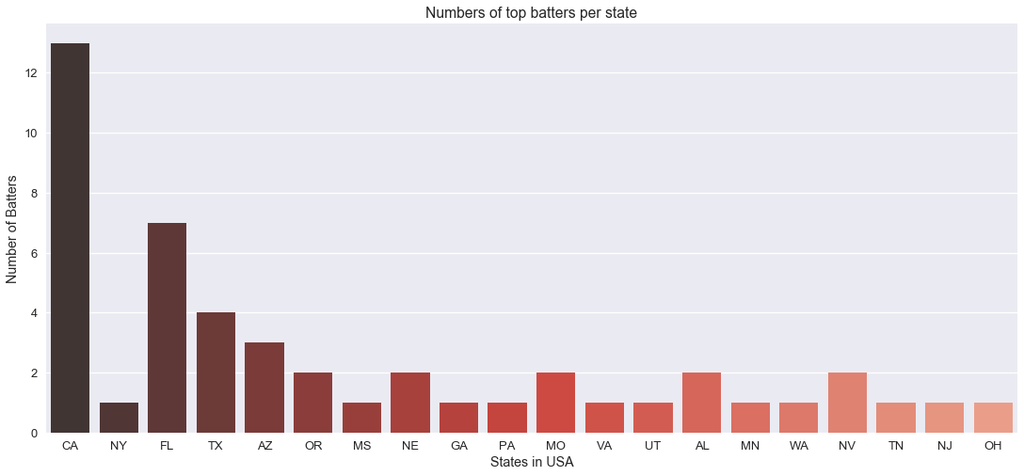

```python
##Plotting Numbers of top batters per state

ax = sns.countplot(x="state", data=batter_school_data, palette="Reds_d");
fig = matplotlib.pyplot.gcf()
fig.set_size_inches(18.5, 8)
ax.set(xlabel='States in USA', ylabel='Number of Batters',title = 'Numbers of top batters per state')
```

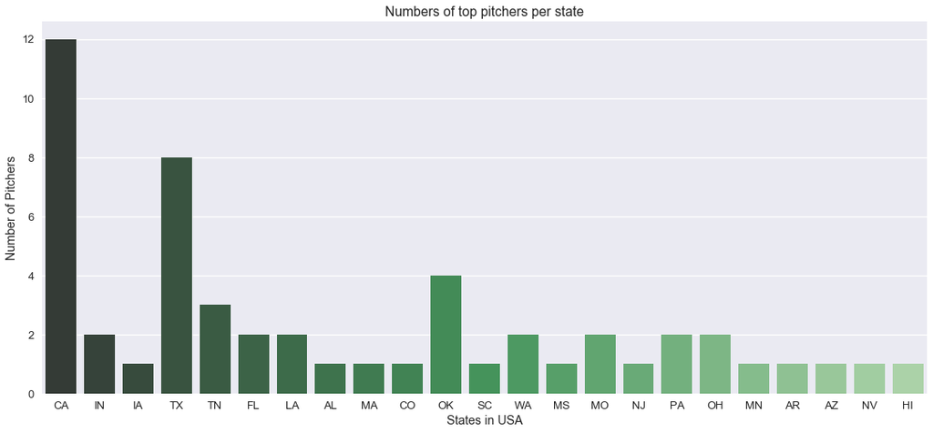

```python
##Plotting Numbers of top pitchers per state

ax = sns.countplot(x="state", data=pitcher_school_data, palette="Greens_d");
fig = matplotlib.pyplot.gcf()
fig.set_size_inches(18.5, 8)
ax.set(xlabel='States in USA', ylabel='Number of Pitchers',title = 'Numbers of top pitchers per state')
```

# Observations :

#### As we can see that for finding good Batters the most favourable hotspots/states are California, Florida and Texas. And for Pitchers the most favourable hotspots are California , Texas and Oklahoma.

#### So from this we can conclude that the team scouts should search these states for top class players if they want their teams to win especially California since it shows the highest number of counts of top class players.

#### We can also observe that there are 58 Pitchers and 54 Batters in the top 100 list who doesn't have any school information connected to them. This is quite unusual but this may be due to if the player is a school dropout or he never went for graduation

###### #

### b. What type of players get higher salary than others - a Correlation between salary and performance of players.

```python
##Defining a procedure to calculate correlation of 2 variables
def correlation(x, y):

    std_x = ((x - x.mean())/x.std(ddof=0))
    std_y = ((y - y.mean())/y.std(ddof=0))

    return (std_x * std_y).mean()
```

```python
##Merging Batsmen Data from top 10 teams with salary data and finding out the coorelation between salary and Runs batted in
##by each batsman

batter_salary_data = batter_sorted_data.merge(salary_data, on = 'playerID', how = 'left')
batter_salary_data = batter_salary_data.groupby('playerID',as_index=False).mean()
batter_salary_data['Salary'] =  batter_salary_data['salary'].round()
del batter_salary_data['salary']
del batter_salary_data['yearID']

batting_salary_corr = correlation(batter_salary_data['RBI'], batter_salary_data['Salary'])

##Finding the player with maximum salary
highest_paid_batsman = batter_salary_data.max()
highest_paid_batsman = master_data[master_data['playerID'] == highest_paid_batsman['playerID']]
highest_paid_batsman['Player_Name'] =  highest_paid_batsman['nameFirst'] + ' ' + highest_paid_batsman['nameLast']


print( '{} = {}'.format('correlation between salary and performance of Batsman',batting_salary_corr) )
print('{} = {}'.format('Highest paid Batsman of last 2 decades from the top ten teams' ,highest_paid_batsman.Player_Name.values[0]))
```

```
correlation between salary and performance of Batsman = 0.6606310955264003
Highest paid Batsman of last 2 decades from the top ten teams = Kevin Youkilis
```

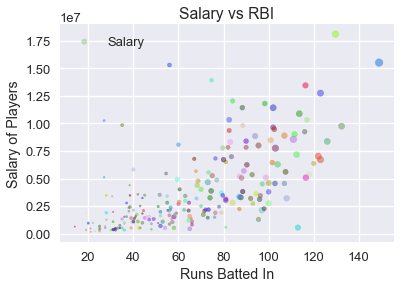

```python
##Plotting a scatterplot btween the above two variables taken for correlation

N = len(batter_salary_data['playerID'].tolist())
colors = np.random.rand(N,3)
plt.scatter(batter_salary_data['RBI'], batter_salary_data['Salary'],s = batter_salary_data['HR']
            , c=colors, alpha=0.5)
plt.legend()
plt.xlabel('Runs Batted In')
plt.ylabel('Salary of Players')
plt.title('Salary vs RBI')

plt.show()
```

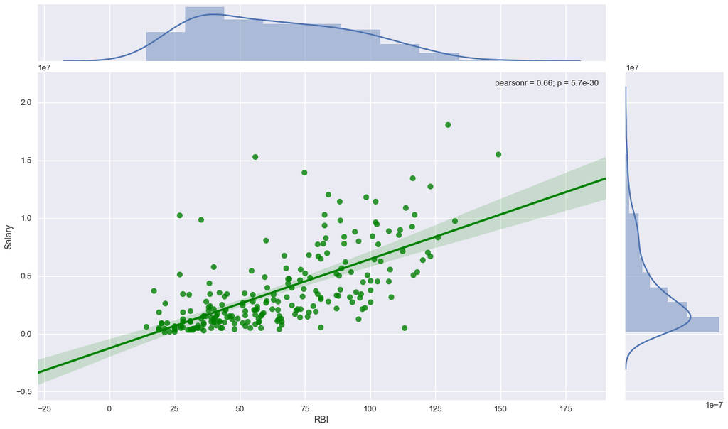

```python
sns.set_context("talk")
sns.jointplot(x="RBI", y="Salary", data=batter_salary_data,kind="reg",joint_kws={'color':'green'})# Scatter and regression all green););
fig = matplotlib.pyplot.gcf()
fig.set_size_inches(18.5, 10.5, forward=True)
sns.plt.show()
```

```python
##Merging Pitcher Data from top 10 teams with salary data and finding out the coorelation between salary and WHIP by each
##pitcher

pitcher_salary_data = pitcher_sorted_data.merge(salary_data, on = 'playerID', how = 'left')
pitcher_salary_data = pitcher_salary_data.groupby('playerID',as_index=False).mean()
pitcher_salary_data['Salary'] =  pitcher_salary_data['salary'].round()
del pitcher_salary_data['salary']
del pitcher_salary_data['yearID']

pitching_salary_corr = correlation(pitcher_salary_data['WHIP'], pitcher_salary_data['Salary'])

##Finding the pitcher with maximum salary
highest_paid_pitcher = pitcher_salary_data.max()
highest_paid_pitcher = master_data[master_data['playerID'] == highest_paid_pitcher['playerID']]
highest_paid_pitcher['Player_Name'] =  highest_paid_pitcher['nameFirst'] + ' ' + highest_paid_pitcher['nameLast']


print( '{} = {}'.format('correlation between salary and performance of Pitchers',pitching_salary_corr))
print('{} = {}'.format('Highest paid Pitcher of the last 2 decade from the top 10 teams' ,highest_paid_pitcher.Player_Name.values[0]))
```

```
correlation between salary and performance of Pitchers = -0.18175458793834973
Highest paid Pitcher of the last 2 decade from the top 10 teams = Chad Zerbe
```

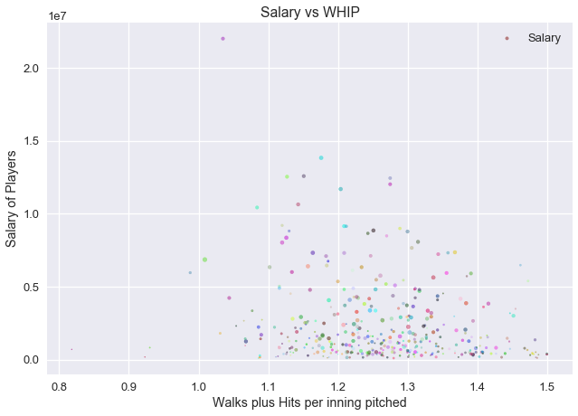

```python
##Plotting a Scatter plot between salary and Earned run average by each pitcher

N = len(pitcher_salary_data['playerID'].tolist())
colors = np.random.rand(N,3)
plt.scatter(pitcher_salary_data['WHIP'], pitcher_salary_data['Salary'],s = pitcher_salary_data['W']
            , c=colors, alpha=0.5)
plt.legend()
plt.xlabel('Walks plus Hits per inning pitched')
plt.ylabel('Salary of Players')
plt.title('Salary vs WHIP')
plt.show()
```

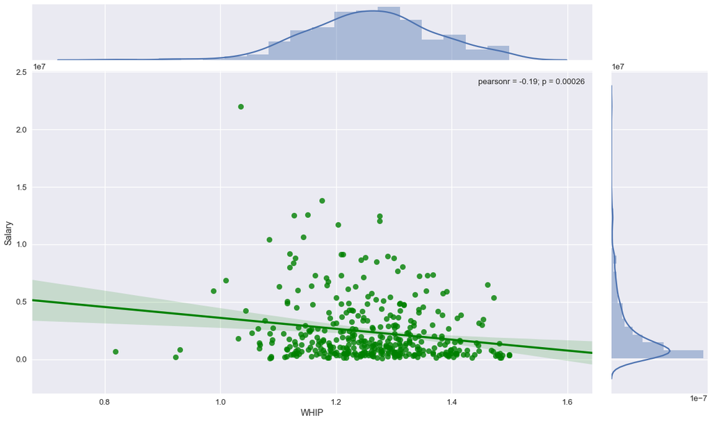

```python
sns.set_context("talk")
sns.jointplot(x="WHIP", y="Salary", data=pitcher_salary_data,kind="reg", joint_kws={'color':'green'})# Scatter and regression all green);
fig = matplotlib.pyplot.gcf()
fig.set_size_inches(18.5, 10.5)
sns.plt.show()
```

# Obervations:

#### WHIP near 1.00 or lower over the course of a season will often rank among the league leaders in Major League Baseball (MLB).

Source: https://en.wikipedia.org/wiki/Walks_plus_hits_per_inning_pitched

###### #

### c. Find the players which have played for a team for more than 12 years?

This a quite small analysis we are just checking which teams have a tendency to retain their players in the long run. Here we are checking stint of a player in a team whether it is more than 12 years. And then plotting the data of teams and their count of players who played for more than 12 years.

```python
##Filtering the data for taking batter stats from the last 2 decades
n_batter_data = batter_data[(batter_data['yearID'] >= 1990)]

##Grouping and extracting fields required for taking out maximum stint of a player in a team.
n_batter_data = n_batter_data[['playerID','stint','teamID']]

n_batter_data = n_batter_data.groupby(['playerID','teamID'],as_index=False).count()

new_batter_data = n_batter_data.groupby(['playerID','teamID'],as_index=False)['stint'].max()

batter_stint_data = new_batter_data[new_batter_data['stint']>12]

batter_stint_data = batter_stint_data.merge(master_data , on = 'playerID',how ='left')


#Filtering Player Names field
batter_stint_data['Player_Name'] =  batter_stint_data['nameFirst'] + ' ' + batter_stint_data['nameLast']

batter_stint_data = batter_stint_data[['playerID','Player_Name','teamID','stint']]


print("Data showing the maximum stint of a Batter in a team")
batter_stint_data.sort_values('stint',ascending=False).reset_index(drop=True)
```

```
Data showing the maximum stint of a Batter in a team
```

|  | playerID | Player_Name | teamID | stint |
| --- | --- | --- | --- | --- |
| 0 | jeterde01 | Derek Jeter | NYA | 20 |
| 1 | riverma01 | Mariano Rivera | NYA | 19 |
| 2 | jonesch06 | Chipper Jones | ATL | 19 |
| 3 | smoltjo01 | John Smoltz | ATL | 18 |
| 4 | biggicr01 | Craig Biggio | HOU | 18 |
| 5 | posadjo01 | Jorge Posada | NYA | 17 |
| 6 | heltoto01 | Todd Helton | COL | 17 |
| 7 | wakefti01 | Tim Wakefield | BOS | 17 |
| 8 | thomafr04 | Frank Thomas | CHA | 16 |
| 9 | hoffmtr01 | Trevor Hoffman | SDN | 16 |
| 10 | willibe02 | Bernie Williams | NYA | 16 |
| 11 | konerpa01 | Paul Konerko | CHA | 16 |
| 12 | martied01 | Edgar Martinez | SEA | 15 |
| 13 | rolliji01 | Jimmy Rollins | PHI | 15 |
| 14 | pettian01 | Andy Pettitte | NYA | 15 |
| 15 | bagweje01 | Jeff Bagwell | HOU | 15 |
| 16 | varitja01 | Jason Varitek | BOS | 15 |
| 17 | bondsba01 | Barry Bonds | SFN | 15 |
| 18 | larkiba01 | Barry Larkin | CIN | 15 |
| 19 | ortizda01 | David Ortiz | BOS | 14 |
| 20 | glavito02 | Tom Glavine | ATL | 14 |
| 21 | francjo01 | John Franco | NYN | 14 |
| 22 | utleych01 | Chase Utley | PHI | 13 |
| 23 | thomeji01 | Jim Thome | CLE | 13 |
| 24 | sosasa01 | Sammy Sosa | CHN | 13 |
| 25 | wrighda03 | David Wright | NYN | 13 |
| 26 | sweenmi01 | Mike Sweeney | KCA | 13 |
| 27 | nagych01 | Charles Nagy | CLE | 13 |
| 28 | rodriiv01 | Ivan Rodriguez | TEX | 13 |
| 29 | roberbr01 | Brian Roberts | BAL | 13 |
| 30 | molinya01 | Yadier Molina | SLN | 13 |
| 31 | mauerjo01 | Joe Mauer | MIN | 13 |
| 32 | liebemi01 | Mike Lieberthal | PHI | 13 |
| 33 | lankfra01 | Ray Lankford | SLN | 13 |
| 34 | howarry01 | Ryan Howard | PHI | 13 |
| 35 | chaveer01 | Eric Chavez | OAK | 13 |
| 36 | youngmi02 | Michael Young | TEX | 13 |

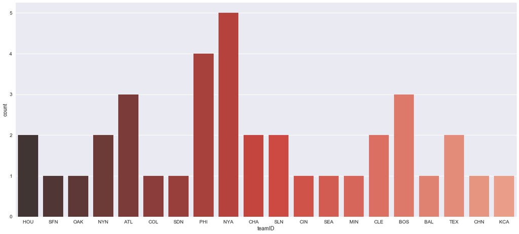

```python
sns.countplot(x="teamID", data=batter_stint_data, palette="Reds_d");
fig = matplotlib.pyplot.gcf()
fig.set_size_inches(24, 10.5)
```

```python
##Filtering the data for taking batter stats from the last 2 decades
n_pitcher_data = pitching_data[(pitching_data['yearID'] >= 1990)]

##Grouping and extracting fields required for taking out maximum stint of a player in a team.
n_pitcher_data = n_pitcher_data[['playerID','stint','teamID']]

n_pitcher_data = n_pitcher_data.groupby(['playerID','teamID'],as_index=False).count()

new_pitcher_data = n_pitcher_data.groupby(['playerID','teamID'],as_index=False)['stint'].max()

pitcher_stint_data = new_pitcher_data[new_pitcher_data['stint']>12]

pitcher_stint_data = pitcher_stint_data.merge(master_data , on = 'playerID',how ='left')


#Filtering Player Names field
pitcher_stint_data['Player_Name'] =  pitcher_stint_data['nameFirst'] + ' ' + pitcher_stint_data['nameLast']

pitcher_stint_data = pitcher_stint_data[['playerID','Player_Name','teamID','stint']]

print("Data showing the maximum stint of a pitcher in a team")
pitcher_stint_data.sort_values('stint',ascending=False).reset_index(drop=True)
```

```
Data showing the maximum stint of a pitcher in a team
```

|  | playerID | Player_Name | teamID | stint |
| --- | --- | --- | --- | --- |
| 0 | riverma01 | Mariano Rivera | NYA | 19 |
| 1 | smoltjo01 | John Smoltz | ATL | 18 |
| 2 | wakefti01 | Tim Wakefield | BOS | 17 |
| 3 | hoffmtr01 | Trevor Hoffman | SDN | 16 |
| 4 | pettian01 | Andy Pettitte | NYA | 15 |
| 5 | francjo01 | John Franco | NYN | 14 |
| 6 | glavito02 | Tom Glavine | ATL | 14 |
| 7 | nagych01 | Charles Nagy | CLE | 13 |

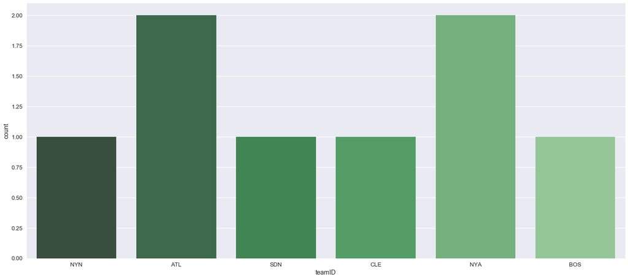

```python
sns.countplot(x="teamID", data=pitcher_stint_data, palette="Greens_d");
fig = matplotlib.pyplot.gcf()
fig.set_size_inches(24, 10.5)
```

# Observations:

#### It seems New York Yankees, Atlanta Braves and Philadelphia Phillies likes to retain their players rather than buying new ones.

###### #

### d. Finding those players who were managers for a team and had played for the same team, this does not include player-managers?

For this question we are changing our constraints of the dataset , previously it was that we will be looking at players who have played after 1989 but now the new constraint is that we need managers who were not player-managers. So for this purpose we will be looking at the whole dataset. First we group each player by their teams and count the times they played for their team. Next we consider those managers who were not player-managers and count their stint in a a team. Finally we merge both the player data and manager data to find those players who were also managers.

We plot the teams and their count of players who were also managers to see which team more often appoints it own player as manager for that team.

```python
##For this question we are considering the whole dataset

u_batter_data = batter_data[['playerID','stint','teamID']]

##Counting the stint of a player in a team
u_batter_data = u_batter_data.groupby(['playerID','teamID'],as_index=False).count()

##Considering those managers who were not player manager
new_manager_data = manager_data[manager_data['plyrMgr'] == 'N']

##Again counting how many times a manager managed a team
new_manager_data= new_manager_data.groupby(['playerID','teamID'],as_index=False).count()[['playerID','teamID','plyrMgr']]

##Merging data with batter data to find all those batsmen who were also managers
batter_manager = pd.merge(new_manager_data, u_batter_data, on=['playerID', 'teamID'], how ='inner')


batter_manager = batter_manager.merge(master_data , on = 'playerID',how ='left')


#Filtering Player Names field
batter_manager['Player_Name'] =  batter_manager['nameFirst'] + ' ' + batter_manager['nameLast']


batter_manager = batter_manager[['playerID','Player_Name','teamID','plyrMgr']]

batter_manager.sort_values('plyrMgr',ascending=False)

batter_manager['Stint'] = batter_manager['plyrMgr']


batter_manager = batter_manager.sort_values('plyrMgr',ascending=False).reset_index(drop=True)[['playerID','Player_Name','teamID','Stint']]

batter_manager
```

|  | playerID | Player_Name | teamID | Stint |
| --- | --- | --- | --- | --- |
| 0 | mcgrajo01 | John McGraw | NY1 | 28 |
| 1 | kellyto01 | Tom Kelly | MIN | 16 |
| 2 | murtada01 | Danny Murtaugh | PIT | 15 |
| 3 | schoere01 | Red Schoendienst | SLN | 14 |
| 4 | harribu01 | Bucky Harris | WS1 | 13 |
| 5 | bochybr01 | Bruce Bochy | SDN | 12 |
| 6 | houkra01 | Ralph Houk | NYA | 11 |
| 7 | jennihu01 | Hughie Jennings | DET | 10 |
| 8 | aloufe01 | Felipe Alou | MON | 10 |
| 9 | bakerdu01 | Dusty Baker | SFN | 10 |
| 10 | larusto01 | Tony LaRussa | OAK | 10 |
| 11 | hargrmi01 | Mike Hargrove | CLE | 9 |
| 12 | mckecbi01 | Bill McKechnie | CIN | 9 |
| 13 | grimmch01 | Charlie Grimm | CHN | 9 |
| 14 | girarjo01 | Joe Girardi | NYA | 9 |
| 15 | bakerde01 | Del Baker | DET | 9 |
| 16 | higgipi01 | Pinky Higgins | BOS | 8 |
| 17 | guilloz01 | Ozzie Guillen | CHA | 8 |
| 18 | martibi02 | Billy Martin | NYA | 8 |
| 19 | mckecbi01 | Bill McKechnie | BSN | 8 |
| 20 | peckiro01 | Roger Peckinpaugh | CLE | 7 |
| 21 | valenbo02 | Bobby Valentine | NYN | 7 |
| 22 | dykesji01 | Jimmy Dykes | CHA | 7 |
| 23 | dierkla01 | Larry Dierker | HOU | 6 |
| 24 | lopezal01 | Al Lopez | CLE | 6 |
| 25 | southbi01 | Billy Southworth | SLN | 6 |
| 26 | southbi01 | Billy Southworth | BSN | 6 |
| 27 | mcaleji01 | Jimmy McAleer | SLA | 6 |
| 28 | stengca01 | Casey Stengel | BSN | 6 |
| 29 | hanlone01 | Ned Hanlon | BLN | 6 |
| ... | ... | ... | ... | ... |
| 193 | ewingbu01 | Buck Ewing | NY1 | 1 |
| 194 | falkbi01 | Bibb Falk | CLE | 1 |
| 195 | griffcl01 | Clark Griffith | NYA | 1 |
| 196 | griffcl01 | Clark Griffith | CIN | 1 |
| 197 | fonsele01 | Lew Fonseca | CHA | 1 |
| 198 | kimmbr01 | Bruce Kimm | CHN | 1 |
| 199 | davenji01 | Jim Davenport | SFN | 1 |
| 200 | robinfr02 | Frank Robinson | CLE | 1 |
| 201 | clarkda05 | Dave Clark | HOU | 1 |
| 202 | callani01 | Jimmy Callahan | CHA | 1 |
| 203 | roberda07 | Dave Roberts | SDN | 1 |
| 204 | roberda07 | Dave Roberts | LAN | 1 |
| 205 | plummbi01 | Bill Plummer | SEA | 1 |
| 206 | perkicy01 | Cy Perkins | DET | 1 |
| 207 | perezto01 | Tony Perez | CIN | 1 |
| 208 | ottme01 | Mel Ott | NY1 | 1 |
| 209 | newmaje01 | Jeff Newman | OAK | 1 |
| 210 | chapmja01 | Jack Chapman | LS1 | 1 |
| 211 | milledo01 | Doggie Miller | SLN | 1 |
| 212 | marioma01 | Marty Marion | SLN | 1 |
| 213 | clarkfr01 | Fred Clarke | PIT | 1 |
| 214 | mcmilro01 | Roy McMillan | NYN | 1 |
| 215 | cochrmi01 | Mickey Cochrane | DET | 1 |
| 216 | coonejo01 | Johnny Cooney | BSN | 1 |
| 217 | mcbrige01 | George McBride | WS1 | 1 |
| 218 | cravebi01 | Bill Craver | NY3 | 1 |
| 219 | masonch01 | Charlie Mason | PH4 | 1 |
| 220 | cubbami01 | Mike Cubbage | NYN | 1 |
| 221 | martibi02 | Billy Martin | MIN | 1 |
| 222 | adcocjo01 | Joe Adcock | CLE | 1 |

223 rows × 4 columns

```python
u_pitcher_data = pitching_data[['playerID','stint','teamID']]

##Counting the stint of a player in a team
u_pitcher_data = u_pitcher_data.groupby(['playerID','teamID'],as_index=False).count()

##Considering those managers who were not player manager
new_manager_data = manager_data[manager_data['plyrMgr'] == 'N']

##Againg counting how many times a manager managed a team
new_manager_data= new_manager_data.groupby(['playerID','teamID'],as_index=False).count()[['playerID','teamID','plyrMgr']]

##Merging data with batter data to find all those pitcher who were also managers
pitcher_manager = pd.merge(new_manager_data, u_pitcher_data, on=['playerID', 'teamID'], how ='inner')


pitcher_manager = pitcher_manager.merge(master_data , on = 'playerID',how ='left')


#Filtering Player Names and plyrMgr field
pitcher_manager['Player_Name'] =  pitcher_manager['nameFirst'] + ' ' + pitcher_manager['nameLast']
pitcher_manager = pitcher_manager[['playerID','Player_Name','teamID','plyrMgr']]
pitcher_manager.sort_values('plyrMgr',ascending=False)
pitcher_manager['Stint'] = pitcher_manager['plyrMgr']


pitcher_manager = pitcher_manager.sort_values('plyrMgr',ascending=False).reset_index(drop=True)[['playerID','Player_Name','teamID','Stint']]

pitcher_manager
```

|  | playerID | Player_Name | teamID | Stint |
| --- | --- | --- | --- | --- |
| 0 | griffcl01 | Clark Griffith | WS1 | 6 |
| 1 | dierkla01 | Larry Dierker | HOU | 6 |
| 2 | dyered01 | Eddie Dyer | SLN | 5 |
| 3 | johnswa01 | Walter Johnson | WS1 | 4 |
| 4 | greenda02 | Dallas Green | NYN | 4 |
| 5 | dykesji01 | Jimmy Dykes | PHA | 3 |
| 6 | greenda02 | Dallas Green | PHI | 3 |
| 7 | lyonste01 | Ted Lyons | CHA | 2 |
| 8 | mathech01 | Christy Mathewson | CIN | 2 |
| 9 | hardeme01 | Mel Harder | CLE | 2 |
| 10 | grimebu01 | Burleigh Grimes | BRO | 2 |
| 11 | chapmbe01 | Ben Chapman | PHI | 2 |
| 12 | burnsto01 | Tom Burns | CHN | 2 |
| 13 | michage01 | Gene Michael | NYA | 2 |
| 14 | blackle01 | Lena Blackburne | CHA | 1 |
| 15 | shawkbo01 | Bob Shawkey | NYA | 1 |
| 16 | sothoal01 | Allan Sothoron | SLA | 1 |
| 17 | walshed01 | Ed Walsh | CHA | 1 |
| 18 | waltebu01 | Bucky Walters | CIN | 1 |
| 19 | newmaje01 | Jeff Newman | OAK | 1 |
| 20 | griffcl01 | Clark Griffith | NYA | 1 |
| 21 | hutchfr01 | Fred Hutchinson | DET | 1 |
| 22 | griffcl01 | Clark Griffith | CIN | 1 |
| 23 | fonsele01 | Lew Fonseca | CHA | 1 |
| 24 | ewingbu01 | Buck Ewing | NY1 | 1 |
| 25 | donovbi01 | Bill Donovan | NYA | 1 |
| 26 | coonejo01 | Johnny Cooney | BSN | 1 |
| 27 | callani01 | Jimmy Callahan | CHA | 1 |
| 28 | burwebi01 | Bill Burwell | PIT | 1 |
| 29 | wilheka01 | Kaiser Wilhelm | PHI | 1 |

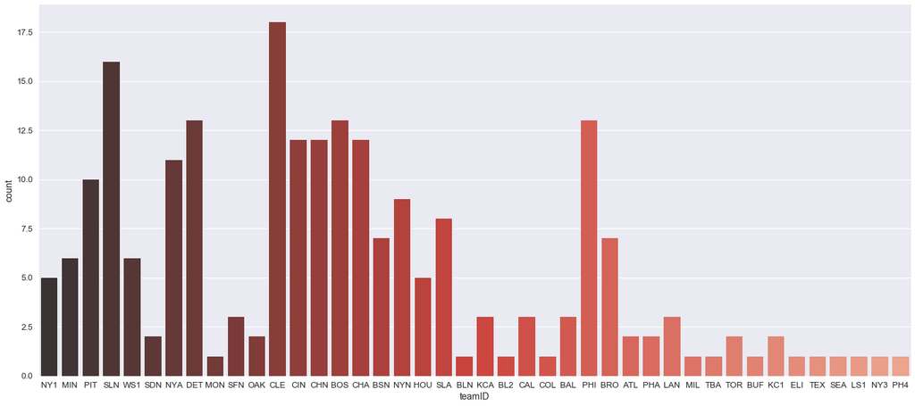

```python
sns.countplot(x="teamID", data=batter_manager, palette="Reds_d");
fig = matplotlib.pyplot.gcf()
fig.set_size_inches(24, 10.5)
```

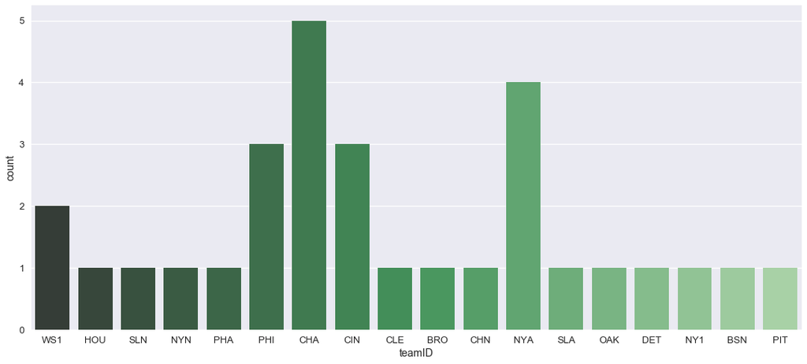

```python
sns.countplot(x="teamID", data=pitcher_manager, palette="Greens_d");
fig = matplotlib.pyplot.gcf()
fig.set_size_inches(18.5, 8)
```

# Observations:

#### Cleveland Indians has a tendency to appoint their past batsmen as managersof their team, as seen from the plot.

#### We can see that John McGraw played for New York Giants(NY1) and also managed the team for about 28 years, maximum stint for any manager.

#### Similarly Chicago white sox(CHA) has a tendency to appoint their former pitchers as Managers. So is New York Yankees(NYA).

#### Clark Griffith managed Washington Senators for 6 years highest for any pitcher.

###### #

### e. Descriptive statistics of salaries of player.

For this purpose we are looking at 1D dataset so we are just calculating the descriptive statistics using the inbuilt functions to see the maximum and minimum player salary ever.

```python
salary_data['salary'].describe()
```

```
count    2.642800e+04
mean     2.085634e+06
std      3.455348e+06
min      0.000000e+00
25%      2.947020e+05
50%      5.500000e+05
75%      2.350000e+06
max      3.300000e+07
Name: salary, dtype: float64
```

```python
salary_data['salary'].median()
```

```
550000.0
```

# Observation:

We can see that the maximum salary that a player got was 33 million dollars and the minimum is 0, this is quite strange. One way to see this is that the player played for free. Maybe in the early days some players played for free. The mean salary is 2,085,634 dollars and the median salary is 550,000 dollars.

###### #

# 6. Conclusion:

#### Another interesting fact was that some player got no salary an entire season. This is very strange but as told above this could be seen as a old data, maybe in the early days of baseball. We cannot be for sure since there is no theoretical reference also.

#### So finally lets hopr the performance of pitchers improve in the near future.

# 7. Bibliography:

#### 1. https://chrisalbon.com/

#### 2.https://en.wikipedia.org

#### 3.https://seaborn.pydata.org/tutorial.html

#### 4.http://stackoverflow.com/

#### 5.https://matplotlib.org/examples/api/barchart_demo.html

#### 6.http://m.mlb.com/glossary/standard-stats

#### 7.http://onlinestatbook.com/2/describing_bivariate_data/calculation.html

#### 8.https://www.kaggle.com/startupsci/titanic/titanic-data-science-solutions